# Do Zero ao Portfólio Publicado - Parte 1/5

- Mostrar o código
- Esconder o código
- Ver o código fonte

Como escolher e preparar o projeto certo para publicar?

Autor

Jennifer Lopes

Esta newsletter é parte 1 de uma série sobre como publicar o que você já sabe fazer. O foco desta edição é uma pergunta específica: como escolher e preparar o projeto certo para publicar primeiro. Ao final, você encontra o link para o **Manual de Perguntas Essenciais para Projetos de Dados**, material de aprofundamento que complementa esta série com os 9 blocos que toda análise precisa considerar antes de começar.

## Por que a maioria dos projetos nunca é publicada

Na semana passada, uma aluna iniciou a mentoria comigo com dois projetos prontos. Código funcionando. Análise completa. Tudo revisado. Nenhum publicado.

Perguntei o que estava impedindo. A resposta foi: “Acho que ainda não está bom o suficiente.”

Esse não é um problema de qualidade técnica. É um problema de **critério**. Quando não existe um critério claro do que significa “pronto para publicar”, qualquer projeto parece incompleto indefinidamente.

O que acontece na prática:

- O projeto fica parado esperando uma última revisão que nunca termina
- A pessoa começa um projeto novo achando que ele será mais fácil de publicar
- Os projetos se acumulam no computador sem nunca serem vistos por ninguém

**Importante**

Portfólio não é prova de perfeição. É prova de como você pensa e resolve problemas. Um projeto publicado com uma decisão bem justificada comunica mais do que dez projetos guardados esperando o momento certo.

## O critério para escolher o projeto certo agora

O primeiro projeto publicado não precisa ser o mais complexo. Precisa ser o mais **explicável**.

Antes de escolher qual projeto publicar, responda estas quatro perguntas. Elas vêm do **Bloco 1 do Manual de Perguntas Essenciais**, que trata de problema e objetivo:

**1. Você consegue escrever o objetivo em uma frase mensurável?**

“Analisar dados de produtividade agrícola” não é um objetivo. “Identificar quais estados brasileiros apresentaram maior crescimento no rendimento de soja entre 2018 e 2022 usando dados da PAM/IBGE” é um objetivo. A diferença está na **métrica de sucesso** e no **critério de encerramento**: você sabe quando a análise está feita porque a pergunta tem resposta.

Se o objetivo exige mais de uma frase para ser explicado, o escopo está largo demais. Reduza o recorte antes de continuar.

**2. Você sabe de onde vieram os dados e consegue documentar isso?**

Além da fonte, documente a **granularidade** dos dados (nível de detalhe), o período coberto e se a amostra representa a **população de interesse** ou apenas um subconjunto. Projetos com fontes opacas ou dados que não podem ser compartilhados criam barreiras para quem tenta reproduzir a análise.

**3. O código roda do início ao fim sem intervenção manual?**

Se alguém clonar o repositório e rodar os scripts em ordem, o resultado deve ser reproduzível. Isso exige caminhos relativos, dependências registradas e ausência de etapas não documentadas.

**4. Você consegue escrever uma conclusão em três parágrafos?**

O primeiro responde o que foi encontrado. O segundo conecta o resultado ao problema original. O terceiro nomeia os **limites da análise**: o que ela não responde, quais dados não estavam disponíveis, o que seria feito diferente com mais tempo ou recursos.

**Dica**

Se você respondeu sim às quatro perguntas, o projeto está pronto para publicar. Se nenhum projeto atual passa nesse filtro, a solução não é esperar. É reduzir o escopo de um projeto existente até que ele passe. Um projeto menor bem documentado é publicável. Um projeto grande mal documentado não é.

## Hipóteses antes dos dados

Um dos pontos que mais diferencia um portfólio de qualidade é a prática de registrar hipóteses **antes** de explorar os dados. Isso vem do **Bloco 7 do Manual**, que trata de formulação de hipóteses.

Formular hipóteses após ver os resultados e apresentá-las como se fossem anteriores é uma prática conhecida como **HARKing** (*Hypothesizing After Results are Known*). É uma das principais causas de resultados não reproduzíveis e de análises que parecem mais conclusivas do que são.

Na prática, antes de rodar qualquer código de análise, documente no README:

- Qual é a **hipótese principal** do projeto?
- A hipótese é **falsificável**? É possível testá-la e encontrar evidência contrária?
- Qual resultado contradiria a hipótese e o que você faria se ele aparecesse?

Isso não precisa ser formal. Um parágrafo antes de os dados serem explorados já é suficiente. O que importa é que o registro existe antes da análise.

**Aviso**

Evite o **viés de confirmação**: a tendência de buscar nos dados apenas o que confirma o que você já acredita. Uma forma de proteger a análise é nomear, antes de começar, qual resultado contradiria sua hipótese.

## O que transforma um script em projeto publicável

Três elementos fazem a diferença entre um script e um projeto que outra pessoa consegue entender e reproduzir.

### Estrutura de pastas com função clara

```r
meu_projeto/
├── data/       # dados brutos: nunca modificar manualmente
├── R/          # scripts numerados por etapa
├── output/     # gráficos e tabelas gerados pelos scripts
├── index.qmd   # análise com narrativa
└── README.md   # contexto, decisões e instruções de reprodução
```

Dentro de `R/`, os scripts são numerados para comunicar a sequência lógica:

```r
R/
├── 01_importacao.R
├── 02_limpeza.R
├── 03_analise.R
└── 04_visualizacao.R
```

### Controle de caminhos e dependências

**`here`** elimina caminhos absolutos que funcionam só na sua máquina:

```r
library(here)

# Em vez de:
read_csv("C:/Usuarios/Jennifer/Documentos/projeto/data/dados.csv")

# Use:
read_csv(here("data", "dados.csv"))
```

**`renv`** registra quais pacotes e versões o projeto usa. Do **Bloco 8 do Manual**, que trata de ferramentas e infraestrutura: o ambiente de desenvolvimento precisa estar isolado e **reproduzível**. Sem isso, diferenças de versão de pacotes produzem resultados diferentes ou erros que não existiam na sua máquina.

```r
renv::init()       # inicializa o controle de dependências
renv::snapshot()   # registra os pacotes usados
renv::restore()    # restaura o ambiente em outra máquina
```

### Narrativa das decisões

O código mostra o que você fez. A narrativa mostra como você pensa. As duas precisam estar no projeto.

Para cada etapa da análise, responda em texto quatro perguntas que vêm do **Bloco 6 do Manual**, sobre comunicação e impacto:

- **Por que essa fonte de dados?** Explique a cobertura, o período e o que ela permite responder que outras fontes não permitem.
- **Por que esse método?** Uma linha justificando a escolha vale mais do que páginas de código sem contexto. Você usou média? Por que não mediana? Você usou regressão linear? Por que não uma alternativa?
- **O que o resultado indica?** Conecte o número ao problema. Não escreva apenas o valor estatístico. Escreva o que aquele resultado significa para quem vai tomar uma decisão com base nele.
- **Quais são os limites?** Nomear os limites do próprio trabalho é sinal de maturidade analítica. Todo projeto tem limitações. Documentá-las demonstra que você entende o alcance da análise.

**Importante**

O código não é o portfólio. A **narrativa das decisões** é. Qualquer pessoa consegue copiar código que funciona. O que não é possível copiar é o raciocínio sobre por que aquele código faz sentido para aquele problema específico.

## Como comunicar para quem vai ler

Um projeto publicado tem sempre dois públicos: quem tem formação técnica e consegue ler o código, e quem não tem e precisa entender os resultados a partir da narrativa.

Antes de publicar, defina:

**Quem é o público-alvo?**

Se for técnico, o código documentado e as decisões metodológicas são suficientes. Se for misto ou não técnico, cada seção precisa de um parágrafo em linguagem acessível explicando o que foi feito e o que foi encontrado, antes de qualquer gráfico ou tabela.

**As incertezas estão visíveis?**

Resultados apresentados sem limites parecem mais sólidos do que são. Um **intervalo de confiança**, uma nota sobre o tamanho da amostra ou uma frase sobre o que os dados não cobrem tornam a análise mais honesta e mais útil para quem vai tomar decisões com base nela.

**O resultado responde a pergunta original?**

Releia o objetivo que você escreveu no início. A conclusão responde diretamente aquela pergunta? Se a conclusão responde uma pergunta diferente, o texto precisa deixar claro o que mudou e por quê.

## A estrutura mínima na prática

O exemplo abaixo mostra como um projeto de produtividade agrícola fica estruturado com os três elementos aplicados.

**Ver código R**

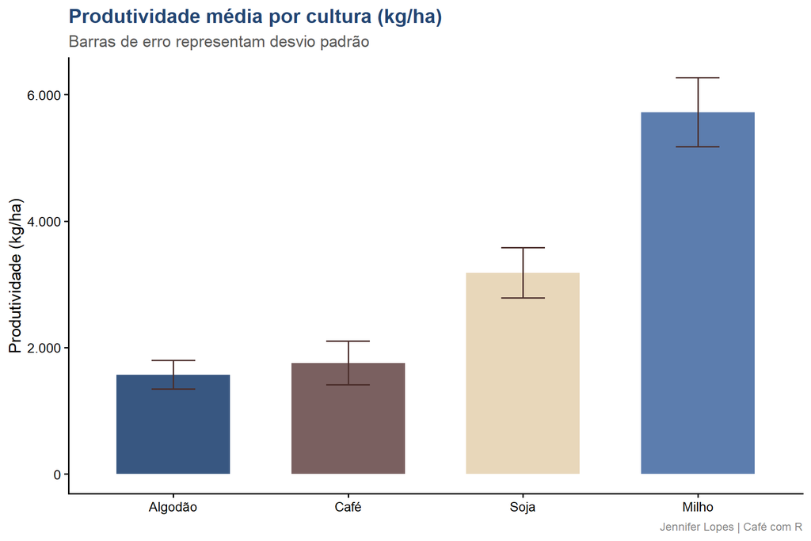

Figura 1: Produtividade média por cultura com desvio padrão. Dados simulados para demonstração.

```r
set.seed(2026)

dados_ex <- data.frame(
  cultura = factor(
    rep(c("Soja", "Milho", "Café", "Algodão"), each = 40)),
  produtividade = c(
    rnorm(40, 3200, 400),
    rnorm(40, 5800, 600),
    rnorm(40, 1800, 300),
    rnorm(40, 1500, 250)))

dados_ex |>
  group_by(cultura) |>
  summarise(
    media   = mean(produtividade),
    dp      = sd(produtividade),
    .groups = "drop") |>
  ggplot(aes(x = reorder(cultura, media), y = media, fill = cultura)) +
  geom_col(width = 0.65, alpha = 0.9) +
  geom_errorbar(
    aes(ymin = media - dp, ymax = media + dp),
    width     = 0.25,
    color     = "#4B2E2B",
    linewidth = 0.7) +
  scale_fill_manual(values = unname(cores_cafe)) +
  scale_y_continuous(labels = label_number(big.mark = ".")) +
  labs(
    title    = "Produtividade média por cultura (kg/ha)",
    subtitle = "Barras de erro representam desvio padrão",
    x        = NULL,
    y        = "Produtividade (kg/ha)",
    caption  = "Jennifer Lopes | Café com R") +
  theme_classic(base_size = 13) +
  theme(
    legend.position = "none",
    plot.title      = element_text(face = "bold", color = "#224573"),
    plot.subtitle   = element_text(color = "#5A5A5A"),
    plot.caption    = element_text(color = "#888888", size = 9))
```

Abaixo do gráfico, a narrativa acompanha o resultado:

> **Decisão metodológica:** a cana-de-açúcar foi excluída desta comparação porque a unidade de medida do rendimento é incompatível com as demais culturas: toneladas por hectare versus quilogramas por hectare. Incluí-la sem transformação produziria uma escala que distorceria a leitura das demais culturas. Essa decisão reduz o escopo da análise mas preserva a **comparabilidade** entre os grupos apresentados.

Esse parágrafo não existe no código. É o que diferencia o projeto.

## O README que o projeto precisa

O README é o primeiro documento que qualquer pessoa lê ao acessar o repositório. Ele precisa responder cinco perguntas sem exigir que o leitor abra nenhum outro arquivo.

```markdown
# Nome do Projeto

## O que este projeto analisa
Uma ou duas frases descrevendo a pergunta central e o resultado encontrado.

## Fonte dos dados
De onde vêm os dados, qual o período coberto e como acessá-los.

## Como reproduzir
renv::restore()
quarto render index.qmd

## Estrutura do projeto
Descrição das pastas e o que cada uma contém.

## Autora
Nome e link para o LinkedIn ou portfólio.
```

Crie o arquivo com:

```r
usethis::use_readme_md()
```

**Dica**

Escreva o README antes de publicar, não depois. O processo de preencher as cinco perguntas identifica os pontos que ainda precisam de atenção no projeto.

## Checklist de publicação

Antes de publicar, confirme cada item:

- O projeto roda do início ao fim sem intervenção manual
- Os caminhos usam `here::here()` e não caminhos absolutos
- O `renv.lock` está atualizado com `renv::snapshot()`
- O objetivo do projeto está escrito em uma frase com **métrica de sucesso** definida
- As hipóteses foram registradas antes da exploração dos dados
- O **viés de confirmação** foi considerado: existe registro do que contradiria a hipótese
- O README responde as cinco perguntas da seção anterior
- Cada seção do documento tem pelo menos uma frase de narrativa explicando a decisão tomada
- As **limitações da análise** estão documentadas
- A conclusão responde diretamente a pergunta original do projeto
- O **público-alvo** está claro e a linguagem do documento é adequada para ele

## Bases de dados abertas para o portfólio

Projetos com dados abertos e documentados são mais fáceis de publicar e mais úteis para quem lê. O Brasil tem fontes de qualidade acessíveis diretamente pelo R.

Tabela 1: Principais fontes de dados abertos brasileiros acessíveis via R.

| Fonte | Pacote R | O que contém |
| --- | --- | --- |
| IBGE/SIDRA | sidrar | Censo, PNAD, produção agrícola, PIB municipal |
| Base dos Dados | basedosdados | Consolidação de dezenas de bases padronizadas |
| DATASUS | microdatasus | Mortalidade, internações, nascimentos |
| INMET | inmetr | Temperatura, precipitação, umidade histórica |
| Portal Transparência | httr2 | Gastos públicos, contratos, servidores |

Exemplo de acesso à PAM via `sidrar`:

```r
library(sidrar)

rendimento <- get_sidra(
  x         = 1612,
  variable  = 214,
  geo       = "State",
  period    = "2022",
  classific = "c81",
  category  = list(c81 = 2713))
```

## Material de aprofundamento

Esta newsletter cobre o essencial para você publicar o primeiro projeto. Para ir além, o **Manual de Perguntas Essenciais para Projetos de Dados** detalha os 9 blocos que toda análise precisa considerar antes de começar:

| Bloco | Foco |
| --- | --- |
| 1. Problema e Objetivo | O objetivo está claro e mensurável? |
| 2. Dados | Os dados existem, são acessíveis e têm qualidade? |
| 3. Contexto e Domínio | Você entende o domínio e os fatores externos? |
| 4. Metodologia | A metodologia é adequada e reproduzível? |
| 5. Ética e Vieses | Há **viés de seleção**, **viés de confirmação** ou riscos éticos? |
| 6. Comunicação e Impacto | O resultado será interpretado e usado corretamente? |
| 7. Hipóteses | As hipóteses foram registradas antes de ver os dados? Há risco de **HARKing**? |
| 8. Ferramentas e Infraestrutura | O ambiente está definido, isolado e documentado? |
| 9. Gestão do Projeto | O projeto tem ciclos de entrega e revisão definidos? |

O manual inclui um case completo de detecção de churn em uma fintech brasileira mostrando como cada bloco foi aplicado na prática, com as decisões tomadas, os problemas encontrados nos dados e o que teria dado errado sem o checklist. É um documento de uso livre, desenvolvido para ser adaptado ao seu contexto.

## O que vem nas próximas edições

Esta foi a parte 1. O foco foi preparar o projeto antes de publicar.

- **Parte 2:** onde e como publicar com Quarto Pub, GitHub Pages e Netlify
- **Parte 3:** como construir um site de portfólio completo com Quarto
- **Parte 4:** como documentar modelos estatísticos no portfólio
- **Parte 5:** como automatizar a publicação com GitHub Actions

**Nota**

Se você chegou até aqui, o próximo passo não é ler mais uma newsletter. É abrir o RStudio, escolher um projeto existente e responder as quatro perguntas da seção de critério. Quando publicar, me marca no LinkedIn. Quero ver o resultado.

**Jennifer Lopes | Consultoria, Mentoria e Treinamentos**

jenniferlopesconsultoriamentoria.netlify.app

De volta ao topo